# Week 3: Logistic Regression

## Week 3 - Theory

```python
EE0848
MACHINE LEARNING
for SP
```

## Last Week

Linear Regression & Model Evaluation

A Practical Introduction with Python/Scikit-Learn

EE0848 - Machine Learning for SP

## Today

Logistic Regression

EE0848 - Machine Learning for SP

## Review: Classification

A type of supervised learning where the goal is to predict a categorical output variable (class label).

Examples:

Spam or not spam

Benign or malignant tumor

Customer will churn or not churn

## Why Not Linear Regression for Classification?

```python
Linear regression outputs any real number, but for classification we need values between 0 and 1 (probabilities).
Outliers can shift the fitted line and change the classification of other points.
We need a model designed for classification — one that outputs probabilities and has a proper cost function for discrete labels.
```

## Classification Decision Boundary

A decision boundary is a surface that separates classes: wᵀx + b = 0

The normal vector w points toward the positive class.

sign(wᵀx + b) returns +1 or −1 depending on which side of the boundary a point falls.

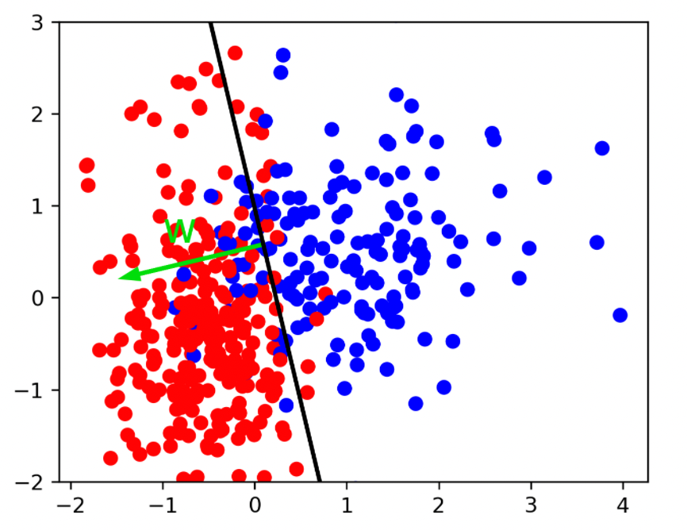

```python
sample from Class 0 at (−2,1)
1(−2)+(−1)(1)+0=−2−1=−3
```

```python
sample from Class 1 at (2,−1)
1(2)+(−1)(−1)+0=2+1=3
```

EE0848 - Machine Learning for SP

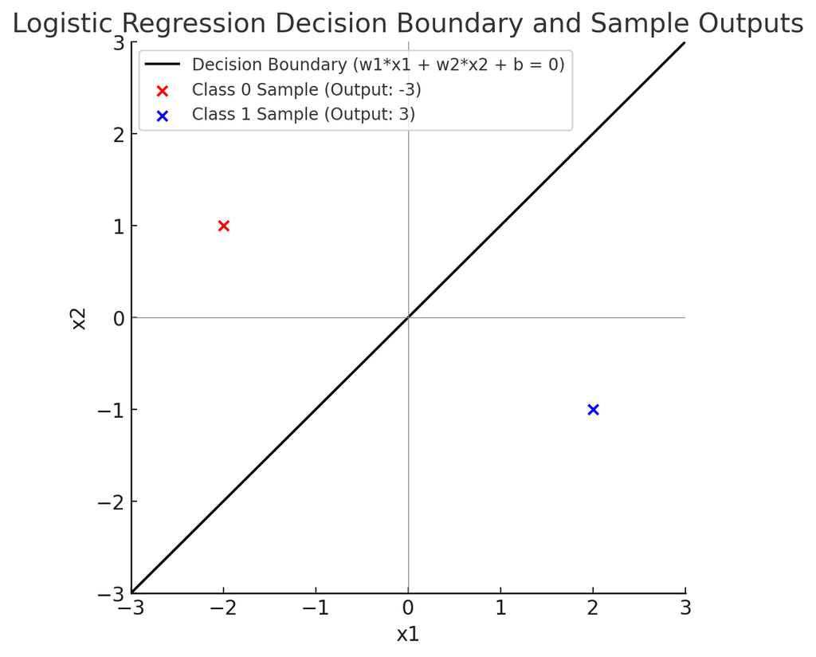

## Classification Example:

Task: Classify emails as spam (1) or not spam (0).

Features:

Number of exclamation marks

Specific keywords (e.g., “free”, “money”)

Sender’s email domain

Model: Logistic Regression

## Introduction to Logistic Regression

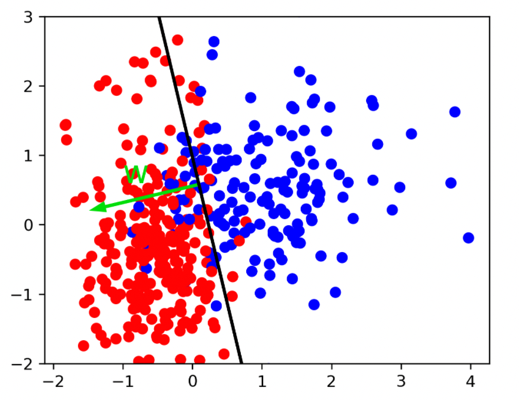

```python
A statistical model used for binary classification.
Predicts the probability that an instance belongs to a particular class.
Uses the sigmoid function to map outputs to [0, 1].
The key idea: sigmoid makes the model differentiable, enabling gradient-based optimization of the cost function.
```

## From Distance to Confidence

```python
The output wᵀx + b scales linearly with distance to the boundary.
Far from boundary → large |wᵀx + b| → high confidence
Near the boundary → small |wᵀx + b| → low confidence
We need a function that maps this distance to a probability → sigmoid
```

EE0848 - Machine Learning for SP

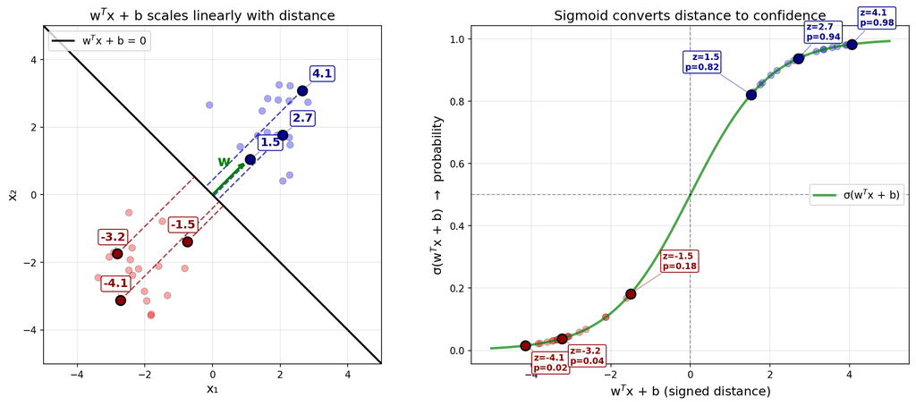

## The Sigmoid Function

Sigmoid

z: Linear combination

Maps any real input to (0, 1).

Interpreted as a probability.

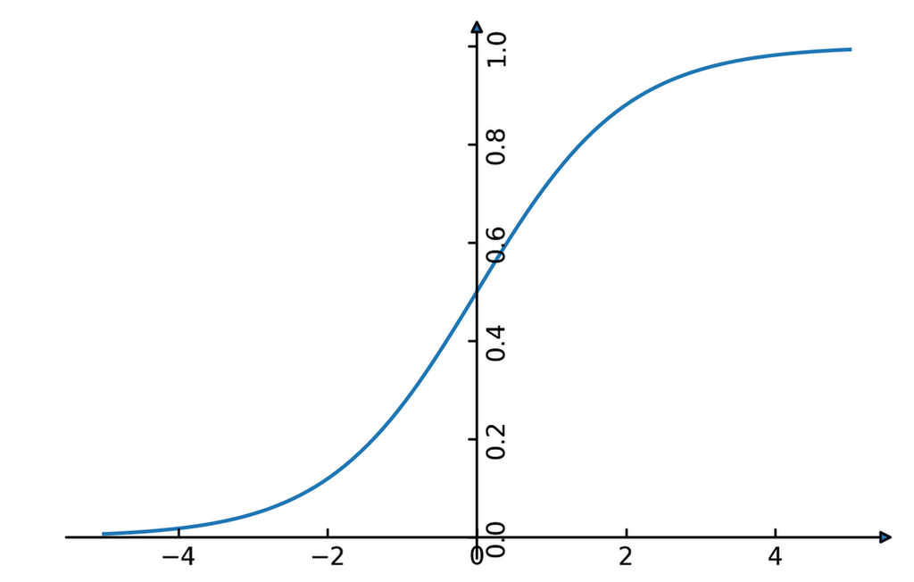

## Interpreting the Output

Sigmoid

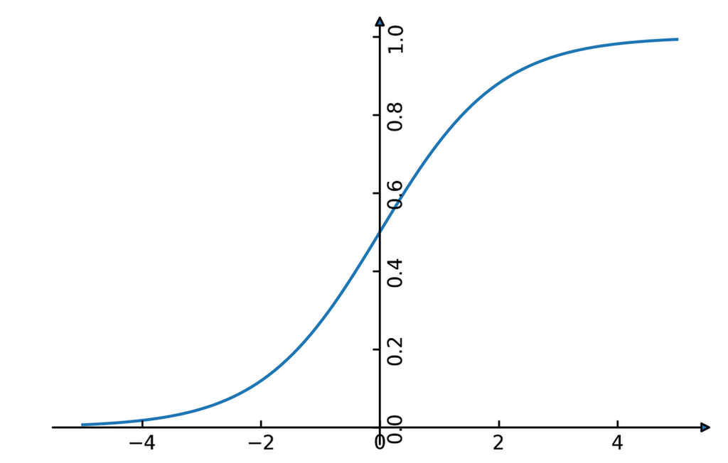

## Logistic Loss function

```python
Squared error cost function for linear regression is convex with a global minimum.
Squared error cost function for a sigmoid function is not convex which means it is not easy to optimize.
```

**y = 0**

EE0848 - Machine Learning for SP

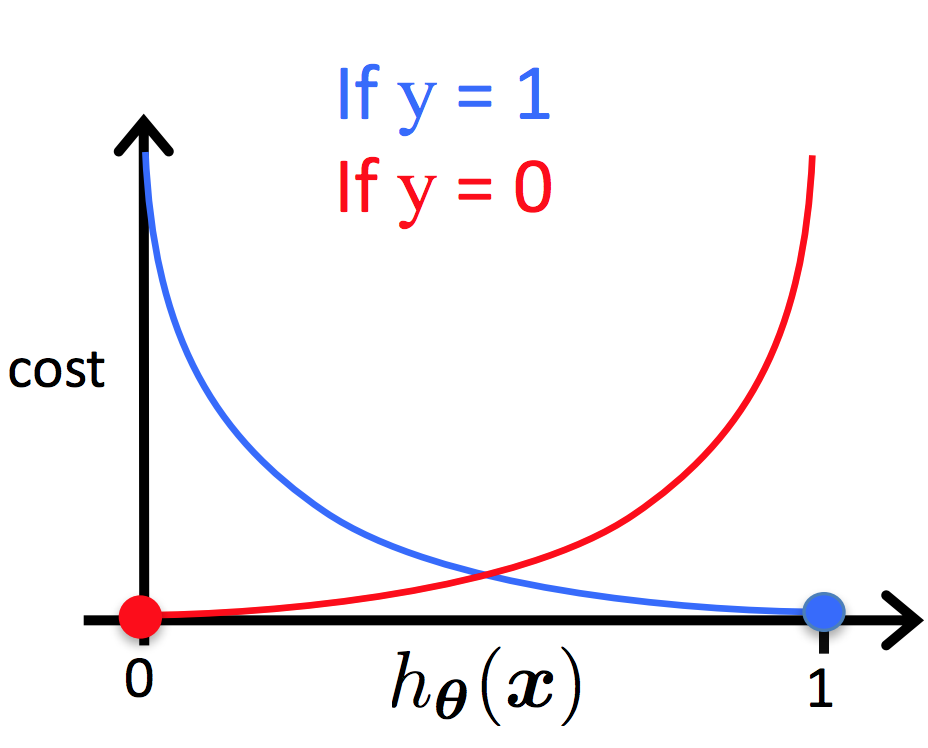

EE0848 - Machine Learning for SP

## Cost function

```python
Cost function is the average of Losses for entire training set
Measures performance for classification models.
Penalizes confidently wrong predictions heavily
```

EE0848 - Machine Learning for SP